Boats Segmentation: Cluster Analysis

**Team names**

## Business Decisions

The core business decision underlying our work is the following: “What customer segments should the company adopt, and how will it help the company to increase its profits?”

The customer segmentation analysis is divided into two major parts:

Factor analysis

Clustering and segmentation analysis, based on factors derived in step 1.

This report is summarizing the effect of step 2.

Based on the factors developed in the previous report we selected 5 segments, which can be named as following:

1. Leisure Novices: the customers boat less frequently than other customer groups, they have less experience boating, and rate themselves as having less expertise than their peers.
2. Established Elderly: these clients constitute the most senior customer group, they have significant experience boating, and high disposable incomes, but are less inclined to buy a boat to establish their status.
3. Affluent Experts: these customers have the highest disposable income and have significant experience boating. They are more likely to repair their own boats, and are very interested in brands that will contribute to their presitige and reputation within the boating commnunity.
4. Price Sensitive DIYs: These customers have the lowest disposable income, and are less concerned with the reputation of their brand. When purchasing a boat they are more concerned with finding an affordable model than a prestigious one.
5. Aspiring Experts: These clients represent the youngest customer group, and as such have less disposable income, however, they are interested in reputable brands and aspire to become the affluent experts later on in life.

OUr decision to create 5 segments was driven by our desire to develop actionable customer groups. By adding a sixth segment we found that the additional detail did not yield material differences between the five customer groups.

## The Data

The data used for clustering and segmentation analysis is behavioral data. We use behavioral data to discover distinct customer needs, and then we use demographics data to discover who those customers are with distinct needs.

## Our Approach

1. Confirm the data in metric
2. Decide whether to scale or standardize the data
3. Decide which variables to use for clustering
4. Define similarity or dissimilarity measures between observations
5. Visualize Individual Attributes and Pair-wise Distances between the Observations
6. Select the clustering method to use and decide how many clusters to have
7. Profile and interpret the clusters
8. Assess the robustness of our clusters

Let's follow these steps.

#### 2. Decide whether to scale or standardize the data

```r
ProjectData_scaled=apply(ProjectData,2, function(r) {if (sd(r)!=0) res=(r-mean(r))/sd(r) else res=0*r; res})
```

While this is typically a necessary step, one has to always do it with care: some times you may want your analytics findings to be driven mainly by a few attributes that take large values; other times having attributes with different scales may imply something about those attributes. In many such cases one may choose to skip step 2 for some of the raw attributes.

We decide to use the unscaled data for now.

#### Step 3. Decide which variables to use for clustering

We felt that data regarding attitudes, needs, and motivations would reveal the most significant and actionable differences between distinct customer groups. As such, we used the five factors developed in our previous study to segment these customer groups.

#### Step 4. Define similarity or dissimilarity measures between observations

In our case we explore two distance metrics: the commonly used **Euclidean distance** as well as a simple one we define manually.

Pairwise Distances between the first 5 observations using The Euclidean Distance Metric

| 1 | 2 | 3 | 4 | 5 |
| --- | --- | --- | --- | --- |
| 0.0 |  |  |  |  |
| 2.0 | 0.0 |  |  |  |
| 1.7 | 1.7 | 0.0 |  |  |
| 3.2 | 1.4 | 2.6 | 0.0 |  |
| 3.2 | 2.4 | 3.6 | 2.4 | 0.0 |

Notice for example that if we use, say, the Manhattan distance metric, these distances change as follows:

Pairwise Distances between the first 5 observations using The Manhattan Distance Metric

| 1 | 2 | 3 | 4 | 5 |
| --- | --- | --- | --- | --- |
| 0.0 |  |  |  |  |
| 4.0 | 0.0 |  |  |  |
| 3.0 | 3.0 | 0.0 |  |  |
| 6.0 | 2.0 | 5.0 | 0.0 |  |
| 4.0 | 4.0 | 7.0 | 4.0 | 0.0 |

Let's now define our own distance metric, as an example. Let's say that the management team of the company believes that two customers are similar if they do not differ in their ratings of the attitudinal questions by more than 2 points. We can manually assign a distance of 1 for every question for which two customers gave an answer that differs by more than 2 points, and 0 otherwise. It is easy to write this distance function in R:

```r
My_Distance_function<-function(x,y){sum(abs(x-y)>2)}
```

Here is how the pairwise distances between the respondents now look like.

Pairwise Distances between the first 5 observations using a simple manually defined Distance Metric

| 1 | 2 | 3 | 4 | 5 |
| --- | --- | --- | --- | --- |
| 0.0 |  |  |  |  |
| 0.0 | 0.0 |  |  |  |
| 0.0 | 0.0 | 0.0 |  |  |
| 0.0 | 0.0 | 0.0 | 0.0 |  |
| 1.0 | 0.0 | 1.0 | 0.0 | 0.0 |

In general a lot of creative thinking and exploration should be spent in this step, and as always one may need to come back to this step even after finishing the complete segmentation process - multiple times.

#### Step 5. Visualize Individual Attributes and Pair-wise Distances between the Observations

or the histogram of all pairwise distances for the euclidean distance:

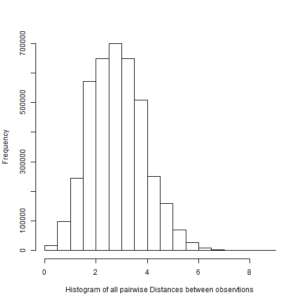

> Visualization is very important for data analytics, as it can provide a first understanding of the data.

#### Step 6. Select the clustering method to use and decide how many clusters to have

In this note we will use two widely used methods: the **Kmeans Clustering Method**, and the **Hierarchical Clustering Method**. Like all clustering methods, these two also require that we have decided how to measure the distance/similarity between our observations. Explaining how these methods work is beyond our scope. The only difference to highlight is that Kmeans requires the user to define how many segments to create, while Hierarchical Clustering does not.

Let's fist use the **Hierarchial Clustering** method, as we do not know for now how many segments there are in our data. Hierarchical clustering is a method that also helps us visualise how the data may be clustering together. It generates a plot called the **Dendrogram** which is often helpful for visualization - but should be used with care. For example, in this case the dendrogram, using the euclidean distance metric from the earlier steps and the ward hierarchical clustering option (see below as well as help(hclust) in R for more information), is as follows:

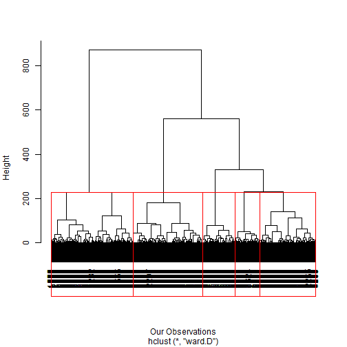

Note that we can draw as many clusters are we choose (e.g. in this case we chose 5 clusters) around the branches of the Dendrogram.

#### Step 7. Profile and interpret the clusters

As discussed previously, we felt that 5 segments provided the most insight and actioability.

1. Leisure Novices: the customers boat less frequently than other customer groups, they have less experience boating, and rate themselves as having less expertise than their peers.
2. Established Elderly: these clients constitute the most senior customer group, they have significant experience boating, and high disposable incomes, but are less inclined to buy a boat to establish their status.
3. Affluent Experts: these customers have the highest disposable income and have significant experience boating. They are more likely to repair their own boats, and are very interested in brands that will contribute to their presitige and reputation within the boating commnunity.
4. Price Sensitive DIYs: These customers have the lowest disposable income, and are less concerned with the reputation of their brand. When purchasing a boat they are more concerned with finding an affordable model than a prestigious one.
5. Aspiring Experts: These clients represent the youngest customer group, and as such have less disposable income, however, they are interested in reputable brands and aspire to become the affluent experts later on in life.

OUr decision to create 5 segments was driven by our desire to develop actionable customer groups. By adding a sixth segment we found that the additional detail did not yield material differences between the five customer groups.

We can also “visualize” the segments using **snake plots** for each cluster. For example, we can plot the means of the profiling variables for each of our clusters to better visualize differences between segments. For better visualization we plot the standardized profiling variables.

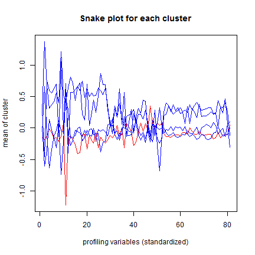

In defining and classifying hte segments, we found the greatest variance with respects to customer's preference for brand prestige, experience boating, and willingness to pay.

We can also compare the averages of the profiling variables of each segment relative to the average of the variables across the whole population. This can also help us better understand whether there are indeed clusters in our data (e.g. if all segments are much like the overall population, there may be no segments). For example, we can measure the ratios of the average for each cluster to the average of the population (e.g. avg(cluster)/avg(population)) and explore a matrix as the following one:

|  | Segment 1 | Segment 2 | Segment 3 | Segment 4 | Segment 5 |
| --- | --- | --- | --- | --- | --- |
| Q1_1_When buying a boat I do a lot of shopping around and visit multiple dealers | 0.9690859 | 1.002434 | 1.057979 | 0.987157 | 1.047886 |
| Q1_2_When buying a boat getting the lowest price is more important than the boat brand | 0.9359895 | 0.7890543 | 0.8409985 | 1.231963 | 1.483208 |
| Q1_3_The brand of boat I buy says a lot about who I am | 0.9588629 | 0.8869082 | 1.245633 | 0.9602056 | 1.218973 |
| Q1_4_I only consider buying a boat from a reputable brand | 0.9968622 | 1.028491 | 1.125279 | 0.8666275 | 1.065688 |
| Q1_5_I am willing to pay a premium for a brand with a reputation for high quality | 0.9808766 | 0.9919057 | 1.144809 | 0.9101104 | 1.097522 |
| Q1_6_Owning a boat is a way of rewarding myself for my hard work | 0.9662153 | 0.9687332 | 1.130594 | 0.9739169 | 1.086328 |
| Q1_7_Owning a boat gives me a sense of achievement | 0.9617622 | 0.9228983 | 1.170111 | 0.9920806 | 1.13653 |
| Q1_8_When buying a boat functionality is more important than style | 0.9547857 | 1.014534 | 0.9699539 | 1.026452 | 1.08733 |
| Q1_9_I see my boat as a status symbol | 0.9507075 | 0.7252923 | 1.392935 | 0.9838145 | 1.450767 |
| Q1_10_When buying a boat I rely more on expert opinion than my own e g consumer reports salespeople | 1.020275 | 0.9384612 | 0.9972348 | 0.9833503 | 1.144664 |
| Q1_11_I tend to perform minor boat repairs and maintenance on my own | 0.5930536 | 1.198594 | 1.233695 | 1.15364 | 1.136116 |
| Q1_12_When it comes to boating I tend to prefer a basic boat with little to no frills | 0.94601 | 0.9633518 | 0.8581458 | 1.105553 | 1.226288 |
| Q1_13_When buying a boat I tend to buy the latest and greatest | 0.959316 | 0.9108911 | 1.183712 | 0.9454208 | 1.263675 |
| Q1_14_When buying accessories for my boat I tend to buy the latest and greatest | 0.9451859 | 0.9434938 | 1.168829 | 0.9576241 | 1.211649 |
| Q1_15_I am serious about the technology on my boat | 0.9339578 | 0.9926421 | 1.150337 | 0.97054 | 1.107433 |
| Q1_16_People tend to come to me for advice about boating | 0.860714 | 0.9812939 | 1.222287 | 0.9989223 | 1.222147 |
| Q1_17_I consider myself more knowledgeable about boating than the rest of my boating peers | 0.8764413 | 0.9733364 | 1.189189 | 1.003122 | 1.226197 |
| Q1_18_Boating gives me a feeling of adventure | 0.9798885 | 0.9756709 | 1.134035 | 0.9638614 | 1.040383 |
| Q1_19_Boating allows me to experience nature | 0.9821438 | 0.9945536 | 1.08385 | 0.9748705 | 1.021011 |
| Q1_20_When not on my boat I often find myself doing boating related activities | 0.8988542 | 0.9612665 | 1.188575 | 0.9907823 | 1.21464 |
| Q1_21_Boating helps me escape from everyday life and relax | 0.9801795 | 0.9954077 | 1.085613 | 0.9818197 | 1.007376 |
| Q1_22_Boating helps me stay active | 0.9636172 | 0.9970196 | 1.102105 | 0.9770498 | 1.046272 |
| Q1_23_Boating allows me to excel in the sports that I am passionate about e g fishing racing water sports | 0.9301592 | 0.968712 | 1.145348 | 0.9992579 | 1.128812 |
| Q1_24_Boating gives me an outlet to socialize with family and or friends | 0.9880551 | 0.9837343 | 1.09663 | 0.9607802 | 1.046448 |
| Q1_25_Being in charge of my boat is very important to me | 0.9243064 | 0.9783949 | 1.151758 | 0.9945396 | 1.123308 |
| Q1_26_Having a powerful boat is what is most important to me | 0.9491322 | 0.864716 | 1.210469 | 0.9814081 | 1.310434 |
| Q1_27_Boating is the number one thing I do with my spare time | 0.9316355 | 0.9235403 | 1.175295 | 0.9912287 | 1.228241 |
| Q1_28_Boating is my true passion in life | 0.9281518 | 0.9364927 | 1.188646 | 0.9827032 | 1.205457 |
| Q1_29_Boating is one of many things I do in my spare time | 0.9668637 | 1.00929 | 1.063911 | 0.9769946 | 1.051049 |
| Q2_How many powerboats do you currently own | 0.8981787 | 1.054106 | 1.012892 | 1.032813 | 1.093041 |

[output cut: 51 more lines]

We note that in many areas thes five segments are quite similar to each other, but this should not overshadow the fact that in some critical attributes the five customer groups are quite unique from each other, and it is in these areas that we can target our marketing to maximize our profitability within each segment.

#### Step 8. Assess the robustness of our clusters

We will skip this step for this exercise. However in practice this is a very important step.